# IS 4487 Lab 11

## Learning Objective

Use Linear Regression to predict the AQI in Utah.

## Outline

- Pull the latest "Daily AQI by County" file from this link: https://aqs.epa.gov/aqsweb/airdata/download_files.html#AQI
- Your target variable will be *AQI", which is the value of the air quality index
- We will focus the analysis on only the air quality in the state of Utah.
- Note that there is a several-month lag in preparing data; you should check to see if your file has a full year of data from January to December. If not, use the previous year.
- The AQI is divided into six categories:

*Air Quality Index*

| (AQI) Values | Levels of Health Concern |
| --- | --- |
| 0-50 | Good |
| 51-100 | Moderate |
| 101-150 | Unhealthy for Sensitive Groups |
| 151 to 200 | Unhealthy |
| 201 to 300 | Very Unhealthy |
| 301 to 500 | Hazardous |

## Load Libraries

➡️ Assignment Tasks

- Load any necessary libraries

```python
import pandas as pd
import numpy as np
import matplotlib.pyplot as plt
import seaborn as sns

from sklearn.model_selection import train_test_split
from sklearn.linear_model import LinearRegression
from sklearn.metrics import mean_squared_error, r2_score
```

## Import Data into Dataframe

➡️ Assignment Tasks

- Pull the latest full year of data using the "Daily AQI by County" files from this link: https://aqs.epa.gov/aqsweb/airdata/download_files.html#AQI
- Make sure to UNZIP the file
- Import data from the air quality dataset into a dataframe
- Describe or profile the dataframe

```python
from google.colab import files
uploaded = files.upload()

df = pd.read_csv('daily_aqi_by_county_2023.csv')
```

Upload widget is only available when the cell has been executed in the current browser session. Please rerun this cell to enable.

```
Saving daily_aqi_by_county_2023.csv to daily_aqi_by_county_2023.csv
```

## Prepare Data

➡️ Assignment Tasks

- Filter the data to use Utah data only
- Create one dummy variable (true/false) for each of the Defining Parameter values
- Create variables for month of year, year, and season
- Perform any other data cleanup needed (remove outliers, nulls, etc.)
- After filtering for Utah, remove the geographical variables that remain (county, state) since those non-numeric values can't be used. Remove any other non-numeric variables.
- Select the data you would like to use in the model. If you aggregate data, you will have to decide whether to use the min, max or mean value for AQI
- Split the data 80/20 for training and testing

```python
df.columns = df.columns.str.strip()

utah_df = df[df['State Name'] == 'Utah'].copy()

utah_df = pd.get_dummies(utah_df, columns=['Defining Parameter'], drop_first=True)

print(df.columns.tolist())
```

```
['State Name', 'county Name', 'State Code', 'County Code', 'Date', 'AQI', 'Category', 'Defining Parameter', 'Defining Site', 'Number of Sites Reporting']
```

```python
utah_df['Date'] = pd.to_datetime(utah_df['Date'])
utah_df['month'] = utah_df['Date'].dt.month
utah_df['year'] = utah_df['Date'].dt.year

def get_season(month):
    if month in [12, 1, 2]:
        return 'Winter'
    elif month in [3, 4, 5]:
        return 'Spring'
    elif month in [6, 7, 8]:
        return 'Summer'
    else:
        return 'Fall'

utah_df['season'] = utah_df['month'].apply(get_season)

utah_df = pd.get_dummies(utah_df, columns=['season'], drop_first=True)
```

```python
utah_df = utah_df.dropna()

utah_df = utah_df.drop(columns=[
    'State Name', 'county Name', 'Category', 'Date', 'Defining Site'
])
```

```python
features = utah_df.drop(columns=['AQI'])
target = utah_df['AQI']
```

```python
X_train, X_test, y_train, y_test = train_test_split(features, target, test_size=0.2, random_state=42)
```

## Create Model

➡️ Assignment Tasks

- Create a simple linear regression to predict AQI based on as many variables as you can use or derive. (for example, sklearn LinearRegression)
- Evaluate the model by displaying the R squared value
- Visualize the correlation between the target variable and at least one of the independent variables

```python
# Create and train the model
model = LinearRegression()
model.fit(X_train, y_train)
```

```
LinearRegression()
```

```python
from sklearn.metrics import r2_score

# Predict using test set
y_pred = model.predict(X_test)

# Evaluate R-squared
r2 = r2_score(y_test, y_pred)
print("R² Score:", round(r2, 4))
```

```
R² Score: 0.1501
```

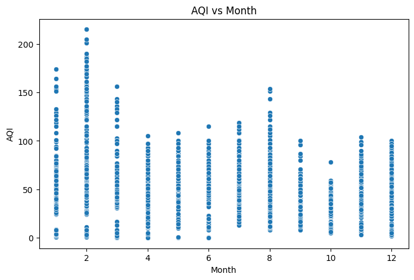

```python
#datetime
utah_df['Date'] = pd.to_datetime(utah_df['Date'])
utah_df['month'] = utah_df['Date'].dt.month


plt.figure(figsize=(8, 5))
sns.scatterplot(x=utah_df['month'], y=utah_df['AQI'])
plt.title('AQI vs Month')
plt.xlabel('Month')
plt.ylabel('AQI')
plt.show()
```

## Make a prediction

➡️ Assignment Tasks

- What would you predict the average AQI to be in January of the upcoming year?

```python
jan_sample = pd.DataFrame({
    'month': [1],
    'year': [2025],
    'Number of Sites Reporting': [utah_df['Number of Sites Reporting'].mean()],

    'Defining Parameter_PM2.5': [1],
    'season_Spring': [0],
    'season_Summer': [0],
    'season_Winter': [1],

}, index=[0])


missing_cols = set(X_train.columns) - set(jan_sample.columns)
for col in missing_cols:
    jan_sample[col] = 0
jan_sample = jan_sample[X_train.columns]


predicted_aqi = model.predict(jan_sample)[0]
print(f"Predicted Average AQI for January 2025: {round(predicted_aqi, 2)}")
```

```
Predicted Average AQI for January 2025: 52.01
```

## OPTIONAL: Compare Air Quality

➡️ Assignment Tasks

- Download the data from several previous years using this website: https://aqs.epa.gov/aqsweb/airdata/download_files.html#AQI
- Append the new data to the previous dataframe
- Use the year as a variable in your regression. Is year a significant factor in predicting AQI?

```python
from google.colab import files


uploaded = files.upload()

import os
print(os.listdir())

df_2022 = pd.read_csv('daily_aqi_by_county_2022.csv')
df_2021 = pd.read_csv('daily_aqi_by_county_2021.csv')
df_2020 = pd.read_csv('daily_aqi_by_county_2020.csv')


combined_df = pd.concat([df_2021, df_2022, df], ignore_index=True)
```

Upload widget is only available when the cell has been executed in the current browser session. Please rerun this cell to enable.

```
Saving daily_aqi_by_county_2020.csv to daily_aqi_by_county_2020 (1).csv
Saving daily_aqi_by_county_2021.csv to daily_aqi_by_county_2021 (1).csv
Saving daily_aqi_by_county_2022.csv to daily_aqi_by_county_2022 (1).csv
['.config', 'daily_aqi_by_county_2023.csv', 'daily_aqi_by_county_2020 (1).csv', 'daily_aqi_by_county_2021 (1).csv', 'daily_aqi_by_county_2021.csv', 'daily_aqi_by_county_2022 (1).csv', 'daily_aqi_by_county_2022.csv', 'daily_aqi_by_county_2020.csv', 'sample_data']
```